# test enrichment

```r
# libraries

library(dplyr)
library(data.table)
library(clusterProfiler) # for gseGO
library(enrichplot)
library(pathview)
library(org.Hs.eg.db)
library(stats) # for fisher test
library(rmarkdown)
library(ggnewscale) # for Visualization of Functional Enrichment Results
library(tidyr)
library(ReactomePA)
library(GSEABase)
```

# Exercise 1

Differential gene expression between two different immune cell types, natural killer (NK) cells and CD4 T helper cells (Th)). The data was generated by RNA sequencing and analyzed using limma.  
Import file NK_vs_Th_diff_gene_exp.csv that contains gene ensembl ID, gene symbols, log2 fold change, t-statistic and raw p-value

```r
# - import csv file NK_vs_Th_diff_gene_exercise_1.csv
path = '/Users/dianaavalos/Desktop/Enrichment_Analysis/Exercises'
NK_vs_Th = fread(
  file.path(path, 'NK_vs_Th_diff_gene_exercise_1.csv'),
  head = TRUE,
  stringsAsFactors = FALSE
)

# - create new column with adjusted p-values
NK_vs_Th$adjusted_pval <-
  p.adjust(NK_vs_Th$P.Value, method = "BH", n = length(NK_vs_Th$P.Value))
# p.adjust.methods # c("holm", "hochberg", "hommel", "bonferroni", "BH", "BY", "fdr", "none")

# - look for CPS1 gene in table
CPS1 = NK_vs_Th[which(NK_vs_Th$symbol == "CPS1")]
CPS1
```

```
##    ensembl_gene_id symbol     logFC         t    P.Value adjusted_pval
## 1: ENSG00000021826   CPS1 -1.637697 -2.079127 0.04496309     0.1565113
```

### Answer the questions of Exercice 1

1. Is CPS1 significantly differentially expressed at alpha=0.05?  
   Yes, pval=0.044
2. How many genes are up-regulated and how many genes are down-regulated

```r
sum(NK_vs_Th$logFC < 0) # 8909
```

```
## [1] 8909
```

```r
sum(NK_vs_Th$logFC > 0) # 11576
```

```
## [1] 11576
```

```r
length(NK_vs_Th$t) # 20485
```

```
## [1] 20485
```

There are 8909 genes down-regulated and 11576 up-regulated

And after BH p-value adjustment?

```r
sum(NK_vs_Th$logFC < 0 & NK_vs_Th$adjusted_pval < 0.05) # 1895
```

```
## [1] 1895
```

```r
sum(NK_vs_Th$logFC > 0 & NK_vs_Th$adjusted_pval < 0.05) # 1957
```

```
## [1] 1957
```

There are 1895 genes down-regulated and 1957 up-regulated after BH p-value adjustment

3. Is CPS1 still differentially expressed after p-value adjustment at alpha=0.05?

```r
CPS1 = NK_vs_Th[which(NK_vs_Th$symbol == "CPS1")]$adjusted_pval
print(CPS1)
```

```
## [1] 0.1565113
```

No, adj pval=0.1565113

# Exercise 2

```r
# - Import the list of genes belonging to the adaptive immune response
adimresp_term2gene = fread(
  file.path(path, 'adaptive_immune_response_geneset_term2gene.csv'),
  head = TRUE,
  stringsAsFactors = FALSE
)
```

- Is the adaptive immune response gene set significantly enriched in genes up-regulated in NK vs Th?

```r
# filter NK_vs_Th with genes belonging to the adaptive immune response
# Determine numbers of up-regulated genes that are within or outside of gene set:

nrow(adimresp_term2gene) #663
```

```
## [1] 663
```

```r
subset_signif <-
  NK_vs_Th %>% subset(NK_vs_Th$adjusted_pval < 0.05)

subset_signif_upreg <-
  subset_signif %>% subset(subset_signif$logFC > 0 )

summary(subset_signif_upreg$symbol %in% adimresp_term2gene$V2)
```

```
##    Mode   FALSE    TRUE
## logical    1882      75
```

We have 3,852 significantly deferentially expressed genes (subset_signif) We have 1,957 significantly up-regulated genes (subset_signif_upreg) We have 75 significantly up-regulated genes belonging to the adaptive immune response We have 1882 significantly up-regulated genes not belonging to the adaptive immune response

```r
subset_not_signif <-
  NK_vs_Th %>% subset(NK_vs_Th$adjusted_pval > 0.05 )

subset_not_significantly_upregulated <-
  NK_vs_Th %>% subset(NK_vs_Th$adjusted_pval > 0.05  |  NK_vs_Th$logFC < 0 )

summary(subset_not_signif$symbol %in% adimresp_term2gene$V2)
```

```
##    Mode   FALSE    TRUE
## logical   16363     270
```

```r
summary(subset_not_significantly_upregulated$symbol %in% adimresp_term2gene$V2)
```

```
##    Mode   FALSE    TRUE
## logical   18118     410
```

I think there is an error in the solution: we want all the genes not significantly up-regulated meaning we want the genes not deferentially expressed but also the ones significantly down-regulated no?

```r
# create contingency table
cont.table <- matrix(c(75, 270, 1882, 16363), ncol = 2, byrow = F)
cont.table_2nd_version <- matrix(c(75, 410, 1882, 18118), ncol = 2, byrow = F)

colnames(cont.table)<-c("up", "not_up")
rownames(cont.table)<-c("in_set", "not_in_set")
cont.table
```

```
##             up not_up
## in_set      75   1882
## not_in_set 270  16363
```

```r
# - Run Fisher test of up-regulated genes
fisher.test(cont.table)
```

```
##
##  Fisher's Exact Test for Count Data
##
## data:  cont.table
## p-value = 8.041e-10
## alternative hypothesis: true odds ratio is not equal to 1
## 95 percent confidence interval:
##  1.835981 3.144708
## sample estimates:
## odds ratio
##   2.414864
```

```r
fisher.test(cont.table_2nd_version)
```

```
##
##  Fisher's Exact Test for Count Data
##
## data:  cont.table_2nd_version
## p-value = 2.983e-05
## alternative hypothesis: true odds ratio is not equal to 1
## 95 percent confidence interval:
##  1.351607 2.268733
## sample estimates:
## odds ratio
##   1.760972
```

The adaptive immune response gene set is significantly enriched in genes up-regulated in NK vs Th as the p value is <0.01

understanding odd’s ratio:

https://towardsdatascience.com/interpretation-of-odds-ratio-and-fishers-exact-test-c6dde394d204#:~:text=It%20is%20called%20the%20Odds,greater%20or%20less%20than%201.

- How many GO gene sets are significant after GSEA (use minGSSize=30, pvalueCutoff=0.1) ?

```r
# - Create named vector of t-statistics and run gsea of built-in GO gene sets:
idType(OrgDb = "org.Hs.eg.db") # to determine allowed gene id type, Genome wide annotation for Human.

gl<-NK_vs_Th$t
names(gl)<-make.names(NK_vs_Th$symbol, unique = T)
gl<-gl[order(gl, decreasing = T)]

# Gene set ontology calling
GO_NK_Th<-gseGO(gl, ont="BP",
                OrgDb = org.Hs.eg.db,
                keyType = "SYMBOL",
                minGSSize=30,
                pvalueCutoff = 0.1,
                seed=T)
# To have a glance at the results table
length(GO_NK_Th@result$pvalue)
```

```
## [1] 562
```

```r
#head(GO_NK_Th@result)
```

There are 562 GO gene sets that are significant after GSEA for pvalueCutoff=0.1 ( length(GO_NK_Th@result$pvalue) )

- Is the adaptive immune response gene set significant? Up-reg. or down-reg.?

```r
# Is the adaptive immune response gene set significant?
GO_NK_Th@result[GO_NK_Th@result$Description=="adaptive immune response",]
```

```
##                    ID              Description setSize enrichmentScore
## GO:0002250 GO:0002250 adaptive immune response     382      -0.3916569
##                  NES      pvalue    p.adjust      qvalues rank
## GO:0002250 -1.849308 9.88491e-10 8.35981e-08 6.534446e-08 1623
##                             leading_edge
## GO:0002250 tags=25%, list=8%, signal=23%
##                                                                                                                                                                                                                                                                                                          …
## GO:0002250 HFE/CD3E/CLU/PDCD1LG2/ADGRE1/JAK3/LEF1/IL18BP/ITK/CD80/ALCAM…
```

The adaptive immune response gene set is significant as the adjusted p-value is 8.35981e-08

normalized enrichment score (NES) is negative (-1.849308) so this gene set is down regulated

- Are the majority of gene sets rather up-regulated or down-regulated?

your list has to be ordered form the most upregulated to the most downregulated so a positive NES for S1 will mean that genes over-represented in that set are upregulated in your dataset. (top of the list) https://www.biostars.org/p/132575/

```r
# - Count the number of negative NES values and the number of positive NES values
summary(GO_NK_Th@result$NES > 0)
```

```
##    Mode   FALSE    TRUE
## logical     102     460
```

There are 460 gene sets rather up-regulated, and 102 down-regulated

# Exercise 3

- First convert the gene symbols to EntrezID to perform a GSEA of KEGG pathways (with argument minGSSize=30).

```r
# - First convert the gene symbols to EntrezID

library(org.Hs.eg.db)
hs <- org.Hs.eg.db
keytypes(org.Hs.eg.db)

# Use bitr to convert Ensembl IDs to ENTREZID and create a named vector of t-statistics
# to provide as gene list to the gseKEGG function, use minGSSize = 30
# NOTE: if the gsea fails, use readRDS to import the pre-computed results
# contained in the file gseKEGG_Nk_vs_Th_results.rds

gene_convert <- bitr(as.character(NK_vs_Th$ensembl_gene_id),
                     fromType="ENSEMBL",
                     toType=c("SYMBOL", "ENTREZID"), OrgDb="org.Hs.eg.db")
head(gene_convert)
```

```
##           ENSEMBL   SYMBOL ENTREZID
## 1 ENSG00000000003   TSPAN6     7105
## 2 ENSG00000000419     DPM1     8813
## 3 ENSG00000000457    SCYL3    57147
## 4 ENSG00000000460 C1orf112    55732
## 5 ENSG00000000938      FGR     2268
## 6 ENSG00000000971      CFH     3075
```

```r
dim(gene_convert) # 16786
```

```
## [1] 16786     3
```

```r
length(unique(gene_convert$ENTREZID)) # 16770
```

```
## [1] 16770
```

```r
# GSEA of KEGG: create a vector of genes that are coded with the EntrezID:
# use the sorted gene list gl previously created:
gl_kegg<-cbind(SYMBOL=names(gl), t=gl)

# merge with converted gene symbols to combine both:
# by default the data frames are merged on the columns with names they both have
gl_kegg<-merge(gl_kegg, gene_convert)
head(gl_kegg)
```

```
##   SYMBOL            t         ENSEMBL ENTREZID
## 1   A1BG  1.129187394 ENSG00000121410        1
## 2    A2M -0.382294217 ENSG00000175899        2
## 3  A2MP1 -1.610033787 ENSG00000256069        3
## 4 A4GALT  0.808365644 ENSG00000128274    53947
## 5   AAAS  0.749990903 ENSG00000094914     8086
## 6   AACS  2.172253591 ENSG00000081760    65985
```

```r
gl_kegg_list<-as.numeric(as.character(gl_kegg$t))
names(gl_kegg_list)<-as.character(gl_kegg$ENTREZID)
gl_kegg_list<-sort(gl_kegg_list, decreasing = T)

# run GSEA of KEGG:
KEGG_NK_Th<-gseKEGG(gl_kegg_list, organism = "hsa", "ncbi-geneid",
                    minGSSize = 30,
                    eps=1e-50,
                    seed=T)
```

Are the majority of gene sets rather up-regulated or down-regulated?

```r
summary(KEGG_NK_Th@result$NES > 0)
```

```
##    Mode   FALSE    TRUE
## logical       9      19
```

Is there a KEGG immune-related gene set coming up? Is there a KEGG Natural killer gene set coming up?

```r
subset(KEGG_NK_Th@result,grepl("immune", KEGG_NK_Th@result$Description))
```

```
##  [1] ID              Description     setSize         enrichmentScore
##  [5] NES             pvalue          p.adjust        qvalues
##  [9] rank            leading_edge    core_enrichment
## <0 lignes> (ou 'row.names' de longueur nulle)
```

```r
subset(KEGG_NK_Th@result,grepl("killer", KEGG_NK_Th@result$Description))
```

```
##                ID                               Description setSize
## hsa04650 hsa04650 Natural killer cell mediated cytotoxicity      96
##          enrichmentScore      NES      pvalue     p.adjust     qvalues rank
## hsa04650       0.6094675 2.430733 2.08159e-11 1.755474e-09 1.43155e-09 1900
##                            leading_edge
## hsa04650 tags=51%, list=13%, signal=45%
##                                                                                                                                                                                                                                                   core_enrichment
## hsa04650 117157/5336/3804/3821/2207/3822/6850/6452/3802/5551/2214/730…
```

There are no KEGG immune-related gene set coming up, but there is 1 KEGG Natural killer gene set coming up

```r
# How many built-in KEGG pathways?
length(KEGG_NK_Th@geneSets)
```

```
## [1] 344
```

If you want to see which genes are included in one of the built-in KEGG pathways, where could you find this information?

```r
subset(KEGG_NK_Th@result,grepl("killer",KEGG_NK_Th@result$Description))$core_enrichment
```

```
## [1] "117157/5336/3804/3821/2207/3822/6850/6452/3802/5551/2214/730…"
```

```r
genes_in_the_killer_cell_pathway= KEGG_NK_Th@geneSets$hsa04650
genes_ID_all_names_killer_cell  <- gl_kegg %>% subset(gl_kegg$ENTREZID %in% genes_in_the_killer_cell_pathway )
head(genes_ID_all_names_killer_cell)
```

```
##      SYMBOL           t         ENSEMBL ENTREZID
## 697    ARAF 0.879272918 ENSG00000078061      369
## 1203    BID  4.79423395 ENSG00000015475      637
## 1264   BRAF 1.280646909 ENSG00000157764      673
## 1670  CASP3 2.631768724 ENSG00000164305      836
## 1918  CD244 6.696470087 ENSG00000122223    51744
## 1919  CD247 4.354611419 ENSG00000198821      919
```

Import the hallmark gene sets and run a GSEA. How many significant gene sets are there?

```r
hallmark_gene_sets<-read.gmt(file.path(path, 'h.all.v7.1.symbols.gmt'))
head(hallmark_gene_sets)
```

```
##                               term    gene
## 1 HALLMARK_TNFA_SIGNALING_VIA_NFKB    JUNB
## 2 HALLMARK_TNFA_SIGNALING_VIA_NFKB   CXCL2
## 3 HALLMARK_TNFA_SIGNALING_VIA_NFKB    ATF3
## 4 HALLMARK_TNFA_SIGNALING_VIA_NFKB  NFKBIA
## 5 HALLMARK_TNFA_SIGNALING_VIA_NFKB TNFAIP3
## 6 HALLMARK_TNFA_SIGNALING_VIA_NFKB   PTGS2
```

```r
length(unique(hallmark_gene_sets$term))

# Run GSEA with the function that allows to use custom gene sets,
# provide the named vector of t statistics
h_NK_vs_Th<-GSEA(gl, TERM2GENE = hallmark_gene_sets,
                eps=1e-50,
                seed=T)
# what is eps? @param eps This parameter sets the boundary for calculating the p value.

# head(h_NK_vs_Th@result)
```

```r
# Number of significant gene sets:
length(which(h_NK_vs_Th@result$p.adjust<=0.05))
```

```
## [1] 4
```

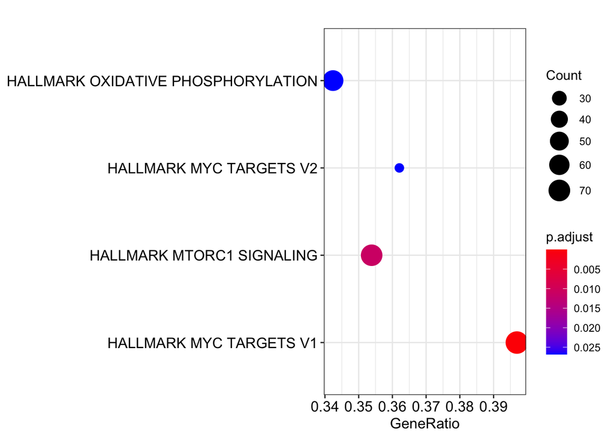

```r
# A quick dotplot of the hallmark results:
dotplot(h_NK_vs_Th, orderBy="p.adjust")
```

# Exercise 4

Create figures for the GSEA results: - barplot of -log10(p-value) of top 10 GO p-values

[figure not shown]

```r
par(mar=c(5,20,3,3))
barplot(rev(-log10(GO_NK_Th@result$pvalue[1:10])),
        horiz = T, names=rev(GO_NK_Th@result$Description[1:10]),
        las=2, xlab="-log10(adj.p-value)",
        cex.names = 0.7,
        col="aquamarine3")
abline(v=-log10(0.05))
```

barcode plot of one of the significant hallmark gene sets (choose one) # TODO

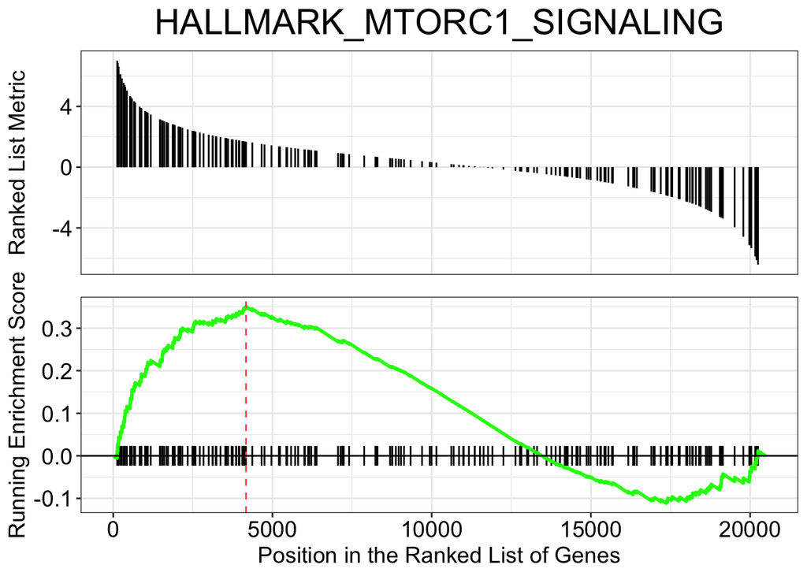

```r
gseaplot(h_NK_vs_Th, geneSetID = "HALLMARK_MTORC1_SIGNALING",
         title="HALLMARK_MTORC1_SIGNALING")
```

```r
h_NK_vs_Th@result$Description[1:4]
```

```
## [1] "HALLMARK_MYC_TARGETS_V1"            "HALLMARK_MTORC1_SIGNALING"
## [3] "HALLMARK_OXIDATIVE_PHOSPHORYLATION" "HALLMARK_MYC_TARGETS_V2"
```

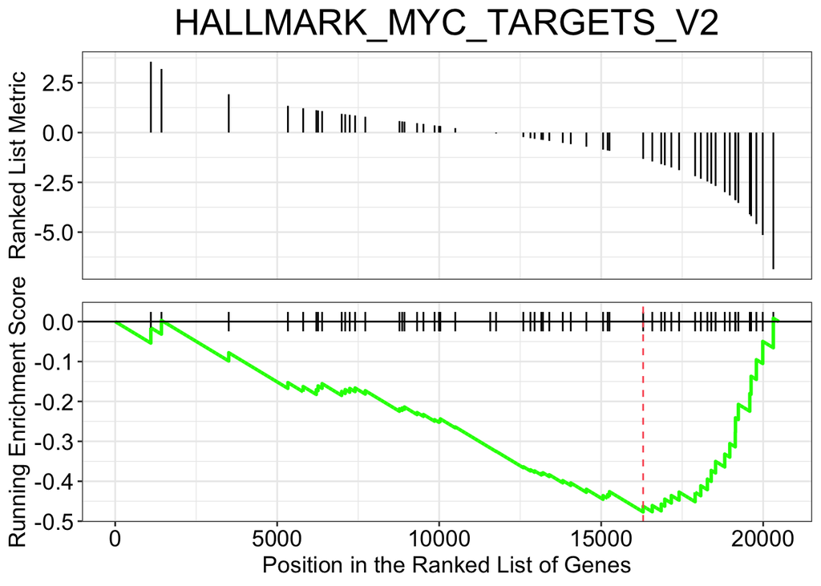

```r
gseaplot(h_NK_vs_Th, geneSetID = "HALLMARK_MYC_TARGETS_V2",
         title="HALLMARK_MYC_TARGETS_V2")
```

```r
h_NK_vs_Th@result$Description[1:4]
```

```
## [1] "HALLMARK_MYC_TARGETS_V1"            "HALLMARK_MTORC1_SIGNALING"
## [3] "HALLMARK_OXIDATIVE_PHOSPHORYLATION" "HALLMARK_MYC_TARGETS_V2"
```

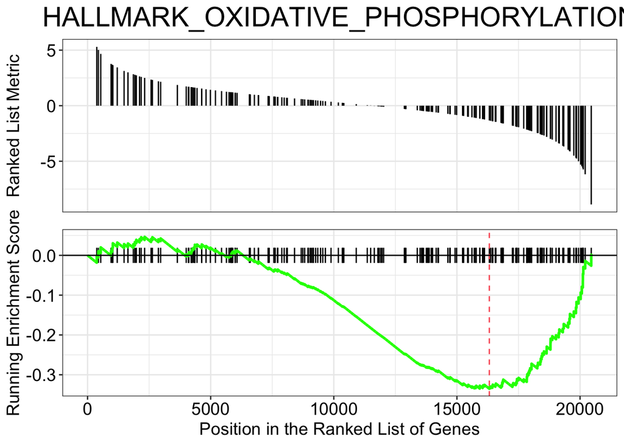

```r
gseaplot(h_NK_vs_Th, geneSetID = "HALLMARK_OXIDATIVE_PHOSPHORYLATION",
         title="HALLMARK_OXIDATIVE_PHOSPHORYLATION")
```

```r
#cnetplot(h_NK_vs_Th, categorySize="pvalue", foldChange=geneList)
```

pathview map for KEGG Natural Killer mediated cytotoxicity (optional: with none-significant genes in grey)

```r
subset_killer=subset(KEGG_NK_Th@result, grepl("killer", KEGG_NK_Th@result$Description))

# pathview with non-significant genes in grey:
# set log fold change of non-significant genes to 0:
NK_vs_Th$logFC_0<-ifelse(NK_vs_Th$adjusted_pval>0.05, 0, NK_vs_Th$logFC)

# create named vector of fold change values:
genePW<-NK_vs_Th$logFC_0
names(genePW)<-NK_vs_Th$symbol
genePW<-na.omit(genePW)

# create pathview map of Natural killer cell mediated cytotoxicity = hsa04650
pathview(gene.data  = genePW,
         pathway.id = "hsa04650",
         species    = "hsa",
         gene.idtype = "SYMBOL")
```

Barplot of NES of the top GO gene sets, with different color for up- or down-reg gene sets:

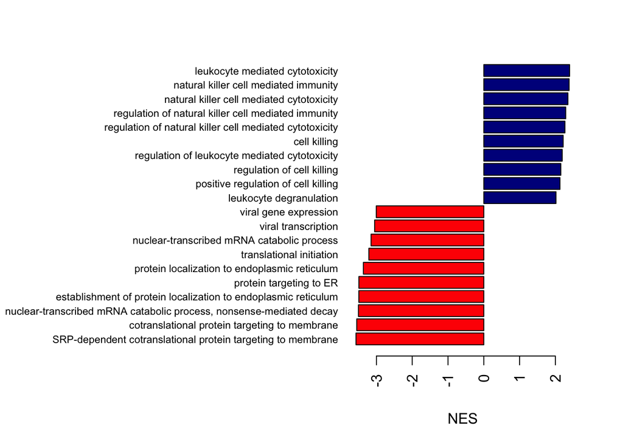

```r
sorted_GO_NK_Th<- GO_NK_Th@result[order(GO_NK_Th@result$NES, decreasing = F),]
sorted_GO_NK_Th$color<-ifelse(sorted_GO_NK_Th$NES<0, "red", "darkblue")

par(mar=c(5,20,3,3))
barplot(sorted_GO_NK_Th$NES[c(1:10, (nrow(sorted_GO_NK_Th)-9):nrow(sorted_GO_NK_Th))],
        horiz = T, names=sorted_GO_NK_Th$Description[c(1:10, (nrow(sorted_GO_NK_Th)-9):nrow(sorted_GO_NK_Th))],
        las=2, xlab="NES",
        cex.names = 0.7,
        col=sorted_GO_NK_Th$color[c(1:10, (nrow(sorted_GO_NK_Th)-9):nrow(sorted_GO_NK_Th))])
```

```r
NK_up_2 <-subset(NK_vs_Th,
              NK_vs_Th$adjusted_pval<=0.05&NK_vs_Th$logFC>3)
NK_up_2<-as.character(NK_up_2$symbol)
```

```r
ego <- enrichGO(NK_up_2, OrgDb='org.Hs.eg.db', ont="BP", keyType = "SYMBOL")
```

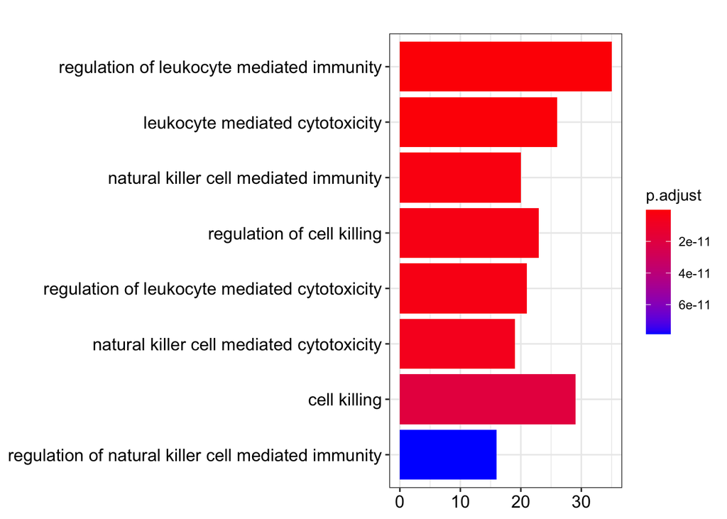

```r
barplot(ego)
```

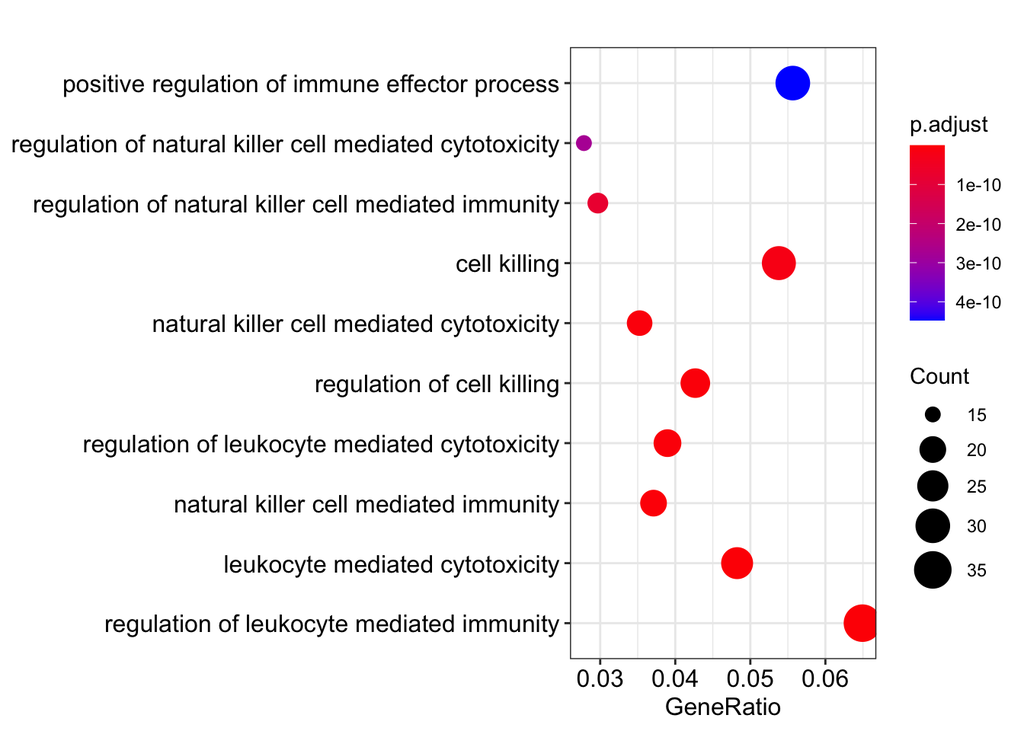

```r
dotplot(ego, orderBy="p.adjust")
```

Which genes are shared by several gene sets:

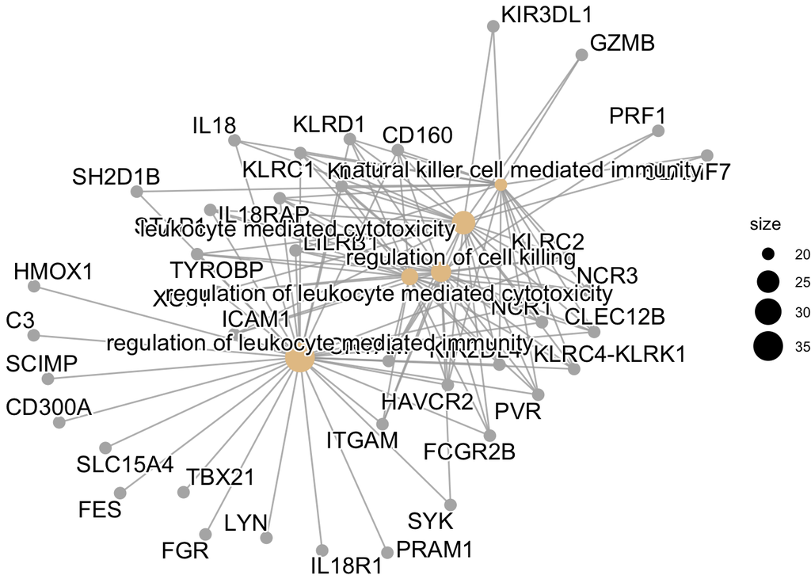

```r
cnetplot(ego, categorySize="pvalue")
```

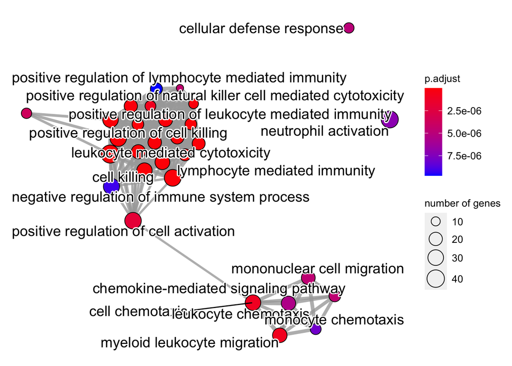

```r
# Similarity among gene sets:
ego2 <- pairwise_termsim(ego)
emapplot(ego2)
```

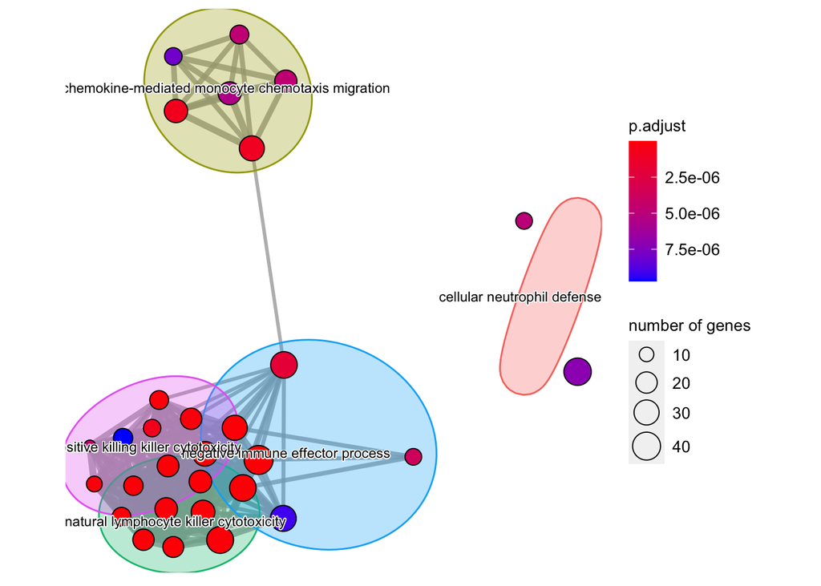

```r
emapplot_cluster(ego2)
```

# Extra exercise for credits

Perform GSEA of the NK vs Th data using the Reactome gene sets downloaded on the MSigDB website.

- How many gene sets are significantly enriched? Generate an ordered barplot of the NES of all genesets, and generate a barcode plot for the gene set with the lowest NES Steps

Use GSEA providing a sorted named vector of t-statistics and the reactome gene sets, use minGSSize=30 NOTE: if the GSEA fails, use readRDS to import the pre-computed results contained in the file “reactomeGSEA_NK_vs_Th_results.rds” - count the number of significant adjusted p-values - use barplot() and gseaplot() for the visualization of the results

```r
# Perform GSEA of the NK vs Th data using the Reactome gene sets downloaded on the MSigDB website.
# download  reactome pathways and gene sets associated

reactome_database <-
  read.table(
    file.path(path, 'c2.cp.reactome.v7.1.symbols.gmt'),
    sep = "\t",
    fill = TRUE,
    header = F,
  )

# - import the reactome gene sets in the file c2.cp.reactome.v7.1.symbols.gmt using read.gmt() , this function doesnt work and shows only first gene of pathway
reactome_gmt <- read.gmt(file.path(path, 'c2.cp.reactome.v7.1.symbols.gmt'))
```

```r
# formating
reactome_database_except_col_1_2 = subset(reactome_database, select = -c(1,2) )

genes_reac_pathway <- reactome_database_except_col_1_2 %>%
  unite("genes",sep=", ")

reactome_database_bis <- merge(reactome_database[,1:2],genes_reac_pathway)

# # i don't know how to integrate this in a function...
# reactome_NK_vs_Th<-GSEA(gl, TERM2GENE = reactome_database_bis,
#                  eps=1e-50,
#                  seed=T)
```

other option:

```r
# https://bioc.ism.ac.jp/packages/3.2/bioc/vignettes/ReactomePA/inst/doc/ReactomePA.html
gl_kegg_list<-as.numeric(as.character(gl_kegg$t))
names(gl_kegg_list)<-as.character(gl_kegg$ENTREZID)
gl_kegg_list<-sort(gl_kegg_list, decreasing = T)
# gl_kegg_list is the list of genes with ENTREZID symbols in decreasing order

reactome <-
  gsePathway(
    gene = gl_kegg_list,
    nPerm = 1000,
    pvalueCutoff = 0.2,
    pAdjustMethod = "BH",
    verbose = FALSE
  )

# enrichPathway also uses reactome ontology
x <- enrichPathway(gene=gene_convert$ENTREZID,pvalueCutoff=0.05, readable=T)
head(summary(x))
```

- How many gene sets are significantly enriched?  
  sum(reactome@result$p.adjust<0.05)  
  [1] 0  
  sum(reactome@result$p.adjust>0.05)  
  [1] 89

for reactome:

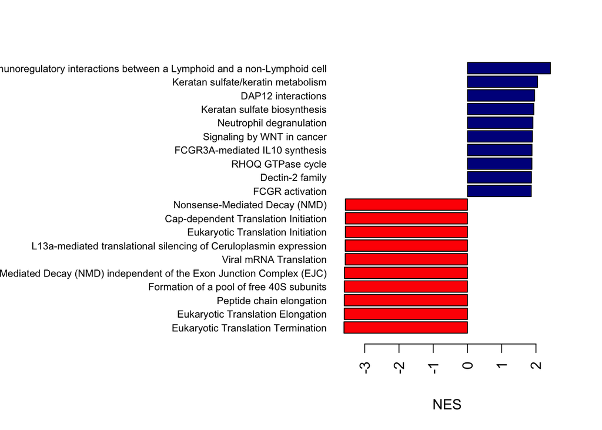

```r
sorted_reactome_NK_Th<- reactome@result[order(reactome@result$NES, decreasing = F),]
sorted_reactome_NK_Th$color<-ifelse(sorted_reactome_NK_Th$NES<0, "red", "darkblue")

par(mar=c(5,20,3,3))
barplot(sorted_reactome_NK_Th$NES[c(1:10, (nrow(sorted_reactome_NK_Th)-9):nrow(sorted_reactome_NK_Th))],
        horiz = T, names=sorted_reactome_NK_Th$Description[c(1:10, (nrow(sorted_reactome_NK_Th)-9):nrow(sorted_reactome_NK_Th))],
        las=2, xlab="NES",
        cex.names = 0.7,
        col=sorted_reactome_NK_Th$color[c(1:10, (nrow(sorted_reactome_NK_Th)-9):nrow(sorted_reactome_NK_Th))])
```

for KEGG

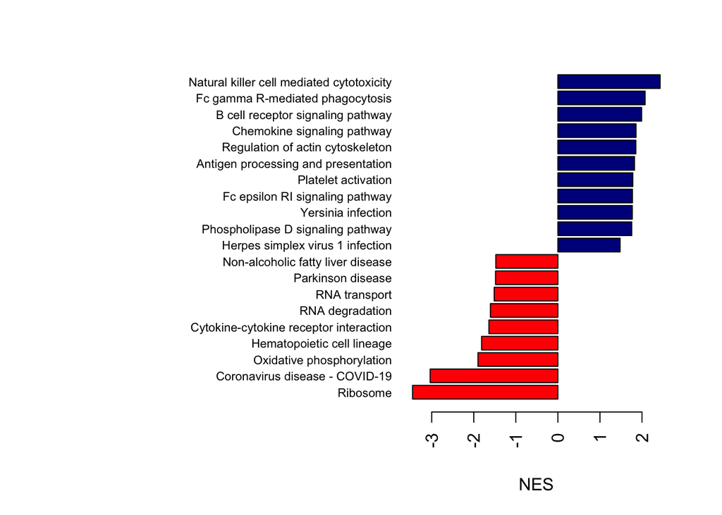

```r
sorted_KEGG_NK_Th<- KEGG_NK_Th@result[order(KEGG_NK_Th@result$NES, decreasing = F),]
sorted_KEGG_NK_Th$color<-ifelse(sorted_KEGG_NK_Th$NES<0, "red", "darkblue")

par(mar=c(5,20,3,3))
barplot(sorted_KEGG_NK_Th$NES[c(1:10, (nrow(sorted_KEGG_NK_Th)-9):nrow(sorted_KEGG_NK_Th))],
        horiz = T, names=sorted_KEGG_NK_Th$Description[c(1:10, (nrow(sorted_KEGG_NK_Th)-9):nrow(sorted_KEGG_NK_Th))],
        las=2, xlab="NES",
        cex.names = 0.7,
        col=sorted_KEGG_NK_Th$color[c(1:10, (nrow(sorted_KEGG_NK_Th)-9):nrow(sorted_KEGG_NK_Th))])
```

Generate an ordered barplot of the NES of all genesets, and generate a barcode plot for the gene set with the lowest NES

```r
sorted_GO_NK_Th$set='GO'
sorted_KEGG_NK_Th$set='KEGG'
sorted_reactome_NK_Th$set='REAC'

all_genesets <- bind_rows(sorted_GO_NK_Th,sorted_KEGG_NK_Th,sorted_reactome_NK_Th)
all_genesets<- all_genesets[order(all_genesets$NES, decreasing = F),]
```

```r
pdf(paste0(path,"/all_genesets_NES.pdf"),         # File name
    width = 8, height = 7, # Width and height in inches
    bg = "white",          # Background color
    paper = "A4")          # Paper size

LENGTH=length(all_genesets$NES)
#LENGTH=100

barplot(
  all_genesets$NES[c(1:LENGTH, (nrow(all_genesets) - 9):nrow(all_genesets))],
  horiz = T,
  names = all_genesets$Description[c(1:LENGTH, (nrow(all_genesets) - 9):nrow(all_genesets))],
  las = 2,
  xlab = "NES",
  cex.names = 0.1,
  col = all_genesets$color[c(1:LENGTH, (nrow(all_genesets) - 9):nrow(all_genesets))]
)

dev.off()
```